# Red Wine Quality Analysis by Jessica

Here below are the scatter plots for other pairs of variables with relatively strong correlation.

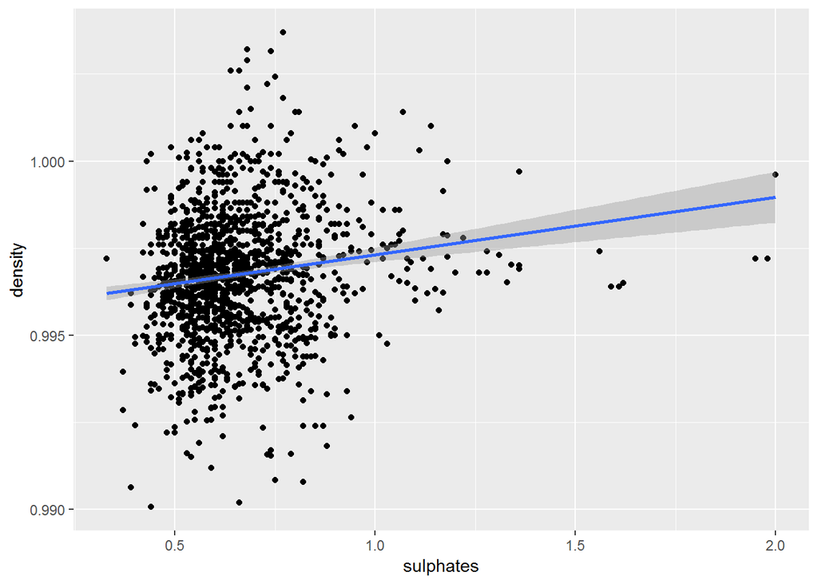

```
##
##  Pearson's product-moment correlation
##
## data:  pf$density and pf$sulphates
## t = 6.0012, df = 1597, p-value = 2.418e-09
## alternative hypothesis: true correlation is not equal to 0
## 95 percent confidence interval:
##  0.1002148 0.1961000
## sample estimates:
##       cor
## 0.1485064
```

Density vs sulphates shows a weak correlation of R=0.15. The scatter points are mainly at left of the plot.

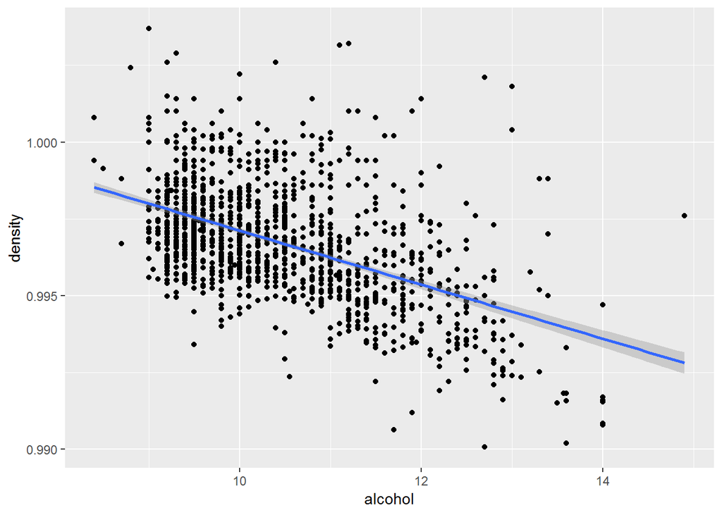

```
##
##  Pearson's product-moment correlation
##
## data:  pf$density and pf$alcohol
## t = -22.838, df = 1597, p-value < 2.2e-16
## alternative hypothesis: true correlation is not equal to 0
## 95 percent confidence interval:
##  -0.5322547 -0.4583061
## sample estimates:
##        cor
## -0.4961798
```

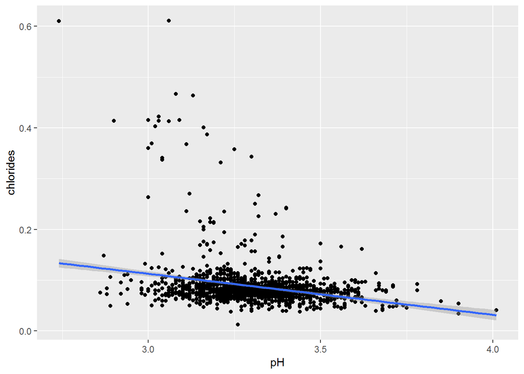

```
##
##  Pearson's product-moment correlation
##
## data:  pf$chlorides and pf$pH
## t = -10.984, df = 1597, p-value < 2.2e-16
## alternative hypothesis: true correlation is not equal to 0
## 95 percent confidence interval:
##  -0.3100195 -0.2188482
## sample estimates:
##        cor
## -0.2650261
```

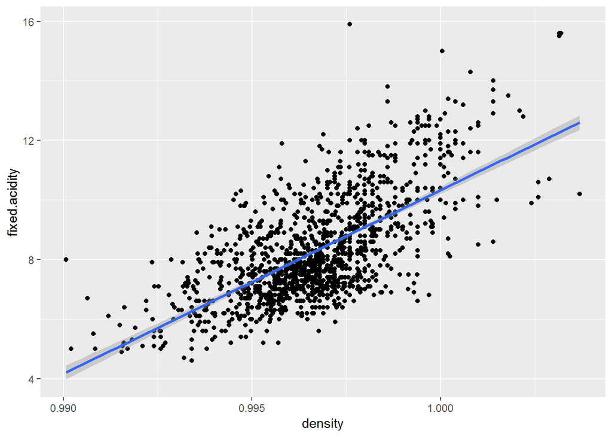

```
##
##  Pearson's product-moment correlation
##
## data:  pf$fixed.acidity and pf$density
## t = 35.877, df = 1597, p-value < 2.2e-16
## alternative hypothesis: true correlation is not equal to 0
## 95 percent confidence interval:
##  0.6399847 0.6943302
## sample estimates:
##       cor
## 0.6680473
```

As the plot we can see fixed acidity vs density shows a strong correlation of R=0.67.

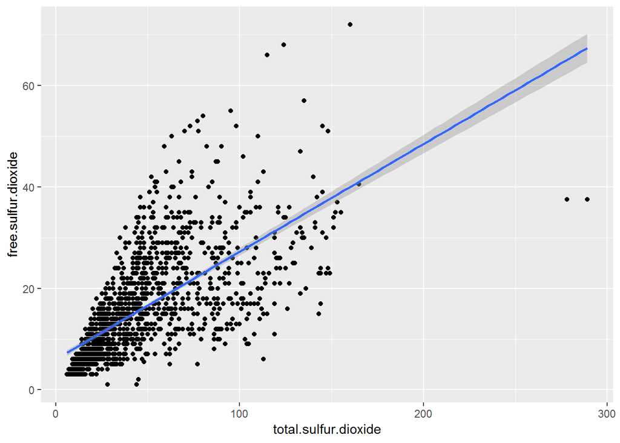

```
##
##  Pearson's product-moment correlation
##
## data:  pf$free.sulfur.dioxide and pf$total.sulfur.dioxide
## t = 35.84, df = 1597, p-value < 2.2e-16
## alternative hypothesis: true correlation is not equal to 0
## 95 percent confidence interval:
##  0.6395786 0.6939740
## sample estimates:
##       cor
## 0.6676665
```

Free.sulfur.dioxide vs total.sulfur.dioxide shows a strong correlation of R=0.67.  
But the relatively higher correlation may due to dependency between these 2 variables.

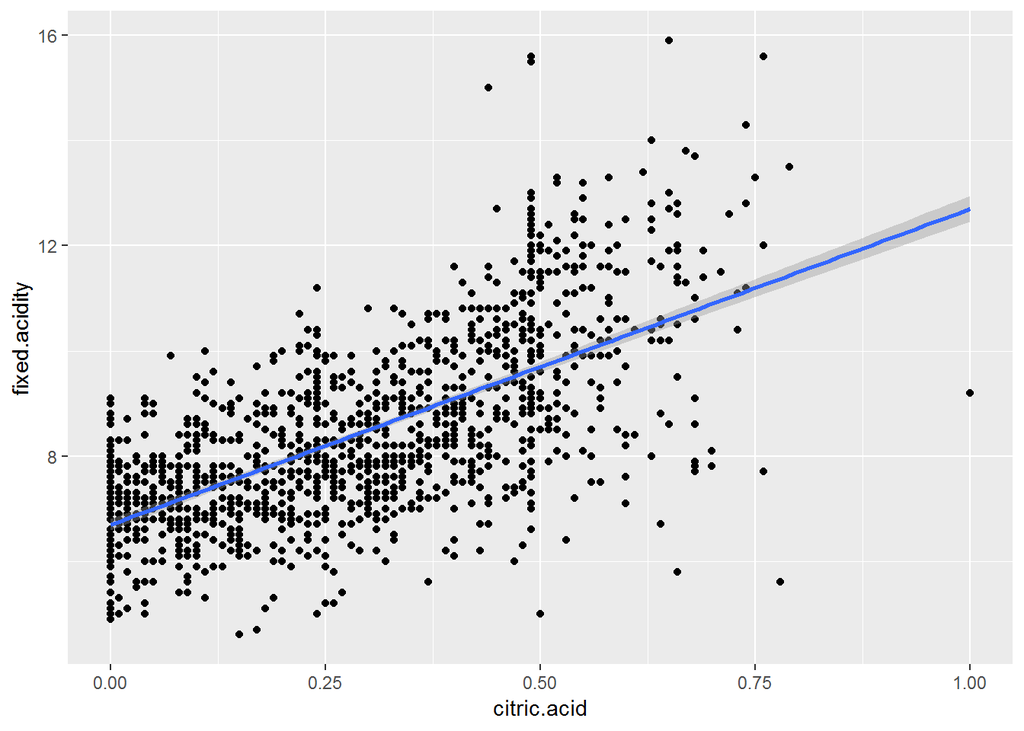

```
##
##  Pearson's product-moment correlation
##
## data:  pf$fixed.acidity and pf$citric.acid
## t = 36.234, df = 1597, p-value < 2.2e-16
## alternative hypothesis: true correlation is not equal to 0
## 95 percent confidence interval:
##  0.6438839 0.6977493
## sample estimates:
##       cor
## 0.6717034
```

Fixed.acidity vs citric.acid shows a strong correlation of R=0.67.  
But the relatively higher correlation may due to dependency between these 2 variables.

# Bivariate Analysis

**1.Talk about some of the relationships you observed in this part of the . How did the feature(s) of interest vary with other features in the dataset?**

# Multivariate Plots Section

In this section, I will conitnue perform analysis of alcohol, olatile acidity and quality level because of their relatively high correlation.

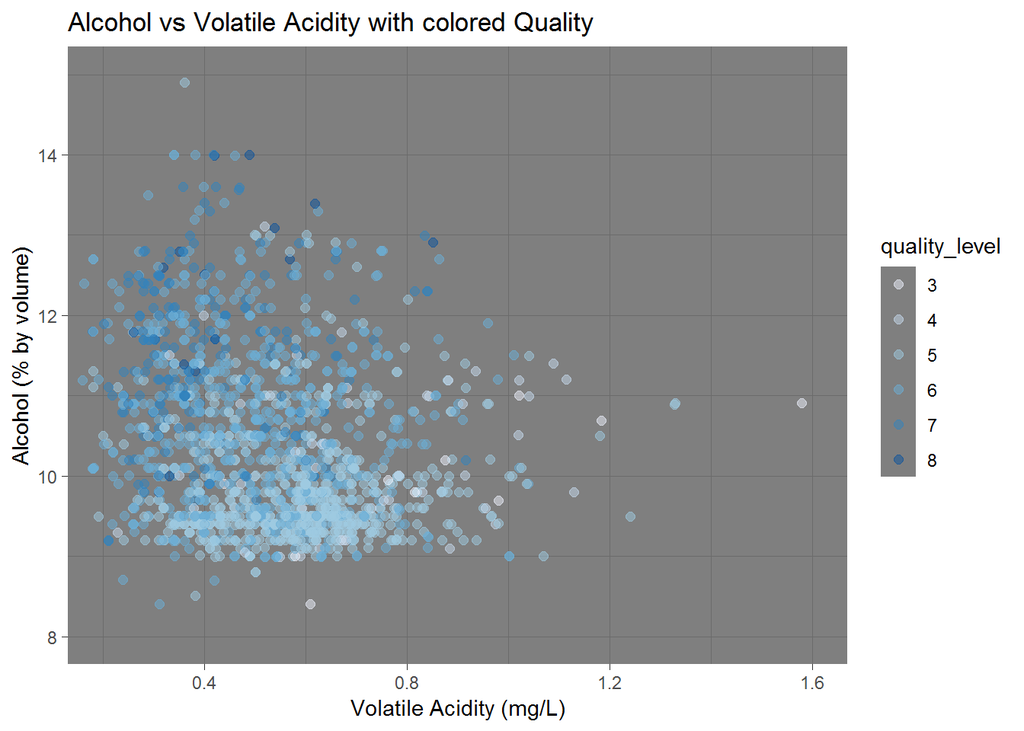

**Observation of Alcohol vs Volatile Acidity with colored Quality**

In the above plot, darkness of the blue points increase with rating of wine quality. Better the quality of red wine, darker is the blue points. For good quality wine within rating 7-8, they have volatile acidity between 0.2 and 0.6 and alcohol between 10 and 14. While for bad qualtiy wine within rating 3-4, they have volatile acidity in a scattered distribution between 0.4 and 1.0 and alcohol between 9 and 11. Wines with rating 5-6 are mainly at the bottom left of the plot. They have volatile acidity between 0.2 to 0.8 and alcohol level below 11.

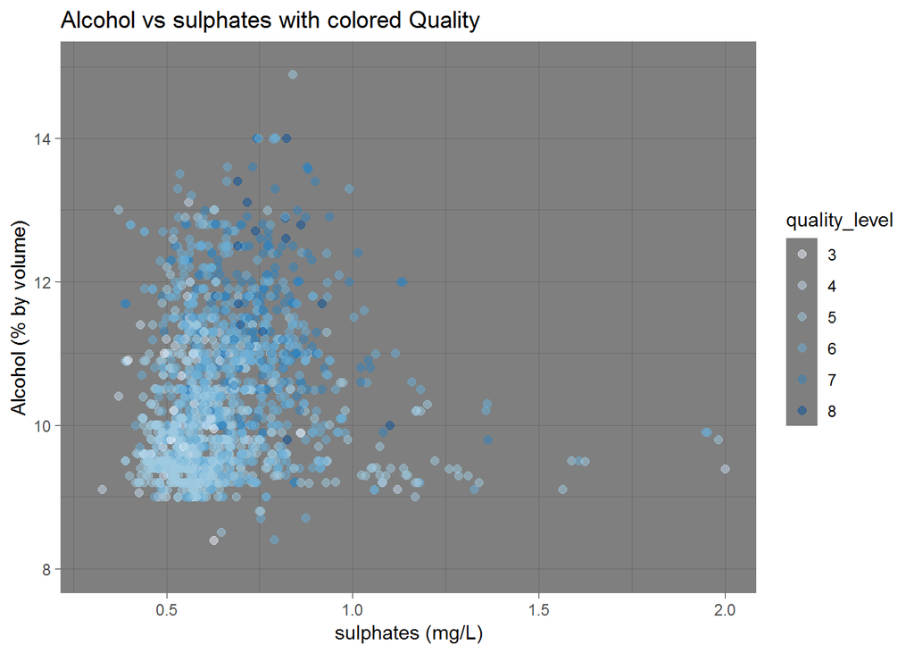

**Observation of Alcohol vs Sulphates with colored Quality**

The scatter points in above plot are mainly distributed at left bottom, sulphates value from 0.3 to 0.7 and alcohol between 9% and 12%, especially for wines with average rating of 5-6. For good quality wine within rating 7-8, sulphates value between 0.5 and 1.0 and alcohol between 10 and 14. While the distribution for these 2 variables for bad qualtiy wine within rating 3-4 is similar as rating of 5-6.

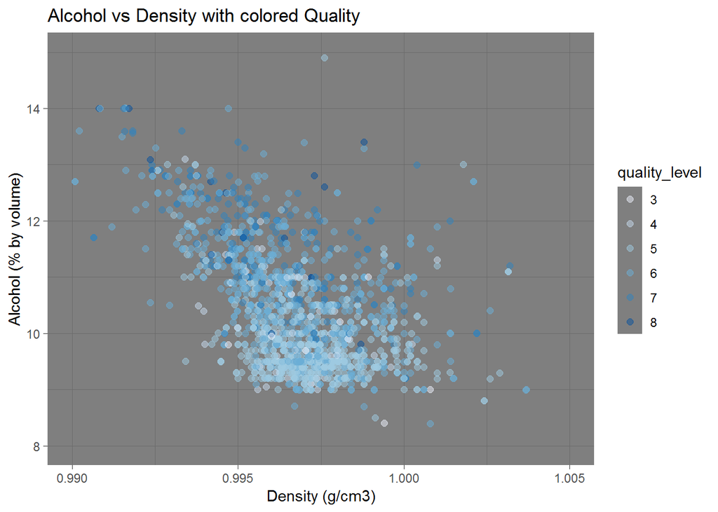

**Observation of Alcohol vs Density with colored Quality**

The scatter points in above plot distribute at central, from which density is between 0.995 and 1.000 g/cm3 and alcohol between 9% and 11% for wines with average rating of 3-4 and 5-6. For good quality wine within rating 7-8, they have density between 0.992 and 0.0.998 and alcohol between 10 and 14.

## Linear Model for quality and multiviriables

```
##
## Calls:
## m1: lm(formula = quality ~ alcohol + volatile.acidity, data = pf)
## m2: lm(formula = quality ~ alcohol + volatile.acidity + density,
##     data = pf)
## m3: lm(formula = quality ~ alcohol + volatile.acidity + density +
##     sulphates, data = pf)
## m4: lm(formula = quality ~ alcohol + volatile.acidity + density +
##     sulphates + chlorides, data = pf)
## m5: lm(formula = quality ~ alcohol + volatile.acidity + density +
##     sulphates + chlorides + pH, data = pf)
##
## ==========================================================================================
##                          m1            m2            m3            m4            m5
## ------------------------------------------------------------------------------------------
##   (Intercept)           3.095***    -18.407        -4.820        -5.677         4.521
##                        (0.184)      (10.298)      (10.387)      (10.335)      (10.708)
##   alcohol               0.314***      0.333***      0.316***      0.300***      0.305***
##                        (0.016)       (0.018)       (0.018)       (0.019)       (0.019)
##   volatile.acidity     -1.384***     -1.365***     -1.219***     -1.164***     -1.069***
##                        (0.095)       (0.096)       (0.097)       (0.097)       (0.101)
##   density                            21.360*        7.392         8.411        -0.506
##                                     (10.228)      (10.331)      (10.281)      (10.561)
##   sulphates                                         0.664***      0.857***      0.848***
##                                                    (0.103)       (0.112)       (0.112)
##   chlorides                                                      -1.653***     -1.929***
##                                                                  (0.394)       (0.401)
##   pH                                                                           -0.419***
##                                                                                (0.120)
## ------------------------------------------------------------------------------------------
##   R-squared             0.317         0.319         0.336         0.343         0.348
##   adj. R-squared        0.316         0.318         0.334         0.341         0.346
##   sigma                 0.668         0.667         0.659         0.655         0.653
##   F                   370.379       248.893       201.751       166.599       141.816
##   p                     0.000         0.000         0.000         0.000         0.000
##   Log-likelihood    -1621.814     -1619.631     -1599.127     -1590.346     -1584.293
##   Deviance            711.796       709.855       691.882       684.325       679.163
##   AIC                3251.628      3249.261      3210.255      3194.692      3184.587
##   BIC                3273.136      3276.147      3242.518      3232.332      3227.604
##   N                  1599          1599          1599          1599          1599
## ==========================================================================================
```

Besides alcohol and volatile acidity, some variables investigate in previous sections are also included in this model (density, sulphates, chlorides).From the statistic data in shows in detail, R-squre is around 0.3 means that this model can only interpret 30% of the variance in the quality of red wine. With the addition of variable, which is from m1 to m5, the R-squared is slightly improved from 0.317 to 0.348 but not very obvious. Hence the linear correlation between quality and those variables are relatively weak. It is aligned with the observation in previous univariable section.

# Multivariate Analysis

**1.Talk about some of the relationships you observed in this part of the . Were there features that strengthened each other in terms of looking at your feature(s) of interest?**

As mentioned above,R-squre in the multivariable linear model is around 0.3 means that the combination of variable alcohol, volatile acid, density, sulphates, chlorides and pH can only interpret 30% of the variance in the quality of red wine. R is slightly increase from 0.317 to 0.348 when increasing the variables. It is a relatively weak correlation model.

**2.Were there any interesting or surprising interactions between features?**  
From the plot, good quality wines seems to have relatively more alcohol and supphates, relatively low density and amount of volatile acidity.

**3.Did you create any models with your dataset? Discuss the strengths and of your model.**

Yes, a multivaribles linear model.  
-*Strength: It is a basic and simple model for data analysis. It is easily understood by reader and performed by analyst.*  
*Limitations:First is the multi-variables must be independent to each other. In this case, there are varibles citric acid, volatile aicd, fixed acidity. I cannot ensure the independency between those varibles so I just chose volatile acid for input in the model. Variables free SO2 and total SO2 are the similar case as acid. Second is a relatively weak linear correlation between variables around 30%. It might not be the best model to predict red wine quality.*

# Final Plots and Summary

## Plot one

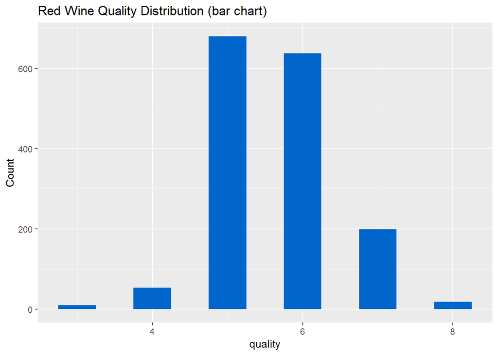

### Description One

Quality is range from 3 to 8 with a normal distribution.

## Plot two

[figure not shown]

### Description Two

Variable alcohol and volatile acidity have relatively strong correlation with red wine quality. From these two boxplots above, we can see that quality and alcohol is positively correlated while volatile acidity is negatively correlated with red wine quality.

## Plot three

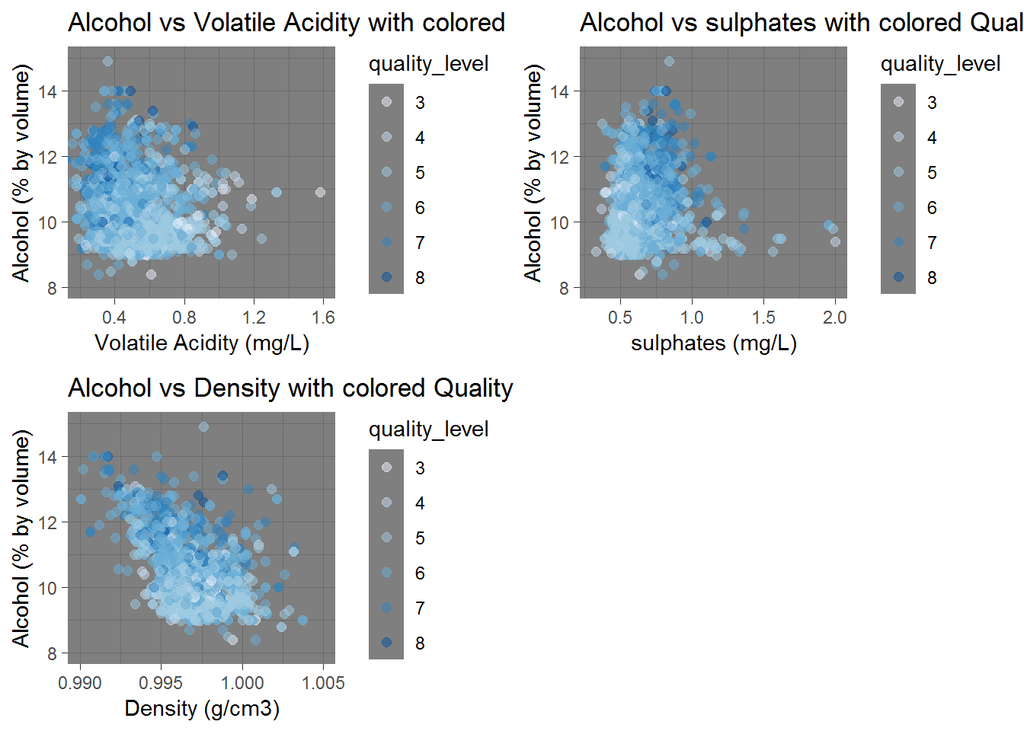

### Description Three

This scatter plot shows the relationship between alcohol, volatile acidity and red wine quality. Higher the alcohol level, lower the volatile acidity, better is the rating of quality (rating 7-8).

# Relection

This red wine quality analysis is performed from data set contains information on 1,599 different red wine. The objective is to determine which chemical properties affect the quality of wine.

**Where did I run into difficulties in the analysis?**

The correlation between each variable and red wine qualtiy is relatively weak.  
I have checked lots of information about how to use the various functions in ggplot to complete the task properly.

**Where did I find successes?**

After performing the boxplots of alcohol, volatile acid and sulphates, I found the trends for those variables with quality. Higher the percentage of the alcohol, better is the red wine quality rating. Volatile acidity is negatively correlated with red wine quality. Lower the volatile acidity, better is the red wine quality rating.

**How could the analysis be enriched in future work (e.g. additional data and analyses)?**

Multivariable linear model, which includes alcohol, volatile acidity, density, sulphates, chlorides and pH can predict only 30% of variance of red wine quality. A better linear model may be done by suggestions like below.  
-*1.Some intersting factors to red wine quality can be included in the dataset, such as the production year and location of the red wine.*  
-*2.The variables in dataset can be separated independently to reduce confusion about fixed acid and citric acid, free SO2 and total SO2.*  
-*3.The sample size of the data set can be larger.*